# Automatic study of aneuploidies control cohort

Nidia Barco Armengol

2025-07-21

## Quality of mean coverage

To ensure data quality, samples with low sequencing coverage were excluded. Specifically, any sample with a mean coverage across autosomes below 50 was considered low quality and removed from further analysis.

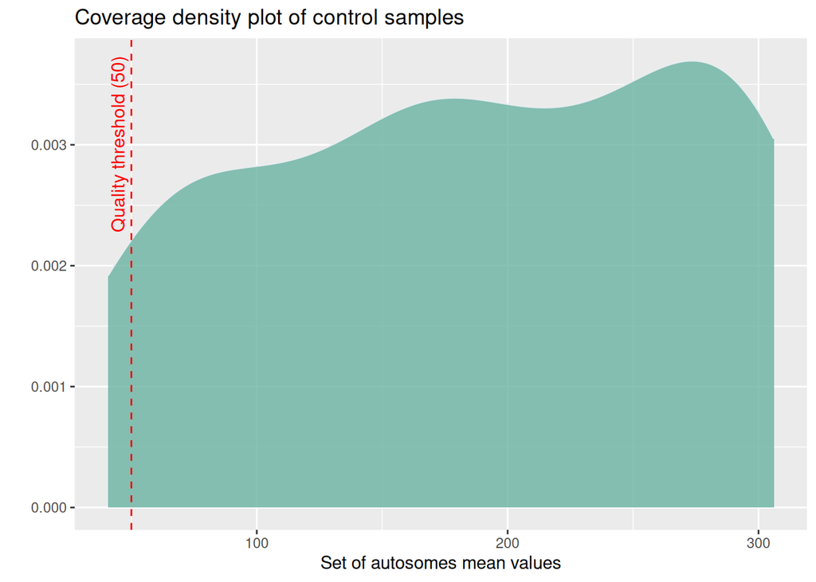

**Samples before filtering:** 50  
**Samples after filtering:** 47

## Coverage analyses of bed files

#### Chr1

#### Chr2

#### Chr3

#### Chr4

#### Chr5

#### Chr6

#### Chr7

#### Chr8

#### Chr9

#### Chr10

#### Chr11

#### Chr12

#### Chr13

#### Chr14

#### Chr15

#### Chr16

#### Chr17

#### Chr18

#### Chr19

#### Chr20

#### Chr21

#### Chr22

## Study of autosomes

To analyze the autosomes, the average coverage value for each autosome in the control samples was calculated. Then, different normalizations were applied by dividing this value either by the average coverage of each other autosome individually or by the average coverage of all autosomes except the one being studied.

For each autosome and normalization method, the standard deviation of these normalized values across all samples was calculated. The standard deviation measures how much the data varies and helps us identify the normalizations that allow better clustering of the cohort samples.

In addition, synthetic samples with varying percentages of mosaic aneuploidies are generated. This helps determine the minimum percentage of mosaicism required for a sample to clearly stand out from the control group.

### Top 3 Normalizations

To detect these differences, we perform Principal Component Analysis (PCA) separately for each autosome, using data normalized by the three best normalization methods. PCA reduces the data to its most important components, and we focus on the first principal component (PC1), which explains the largest variation.

Outliers are identified based on:

The quartiles Q1 and Q3, which represent the 25th and 75th percentiles of the data.

The interquartile range (IQR), calculated as Q3 minus Q1.

Samples with PC1 values lying beyond a strict cutoff—more than 5.5 times the IQR below Q1 or above Q3—are considered outliers, meaning they differ significantly from the control group.

This approach is also used to determine which synthetic samples, created with different percentages of mosaicism for each autosome, show significant differences from the control group according to the formula described above.

#### Chr1

Top 3 normalizations

| Normalized_by | SD_value |
| --- | --- |
| Norm_all | 0.0048288 |
| Norm_Chr11 | 0.0056747 |
| Norm_Chr4 | 0.0060620 |

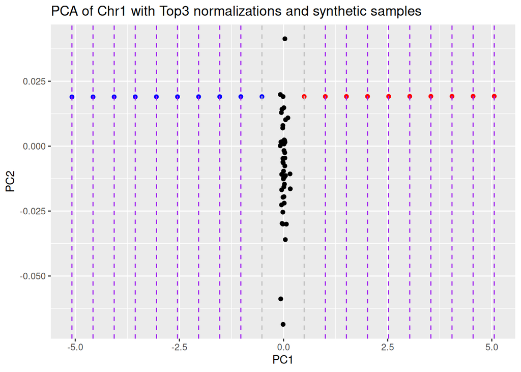

Significant synthetic samples

| Samples | PC1_values |
| --- | --- |
| sample_Chr1_Trisomy10 | -0.5182065 |
| sample_Chr1_Trisomy20 | -1.0250928 |
| sample_Chr1_Monosomy20 | 1.0024526 |
| sample_Chr1_Trisomy30 | -1.5319792 |
| sample_Chr1_Monosomy30 | 1.5093389 |
| sample_Chr1_Trisomy40 | -2.0388655 |
| sample_Chr1_Monosomy40 | 2.0162252 |
| sample_Chr1_Trisomy50 | -2.5457518 |
| sample_Chr1_Monosomy50 | 2.5231116 |
| sample_Chr1_Trisomy60 | -3.0526382 |
| sample_Chr1_Monosomy60 | 3.0299979 |
| sample_Chr1_Trisomy70 | -3.5595245 |
| sample_Chr1_Monosomy70 | 3.5368843 |
| sample_Chr1_Trisomy80 | -4.0664109 |
| sample_Chr1_Monosomy80 | 4.0437706 |
| sample_Chr1_Trisomy90 | -4.5732972 |
| sample_Chr1_Monosomy90 | 4.5506569 |
| sample_Chr1_Trisomy100 | -5.0801835 |
| sample_Chr1_Monosomy100 | 5.0575433 |

#### Chr2

Top 3 normalizations

| Normalized_by | SD_value |
| --- | --- |
| Norm_all | 0.0058496 |
| Norm_Chr4 | 0.0060664 |
| Norm_Chr14 | 0.0062588 |

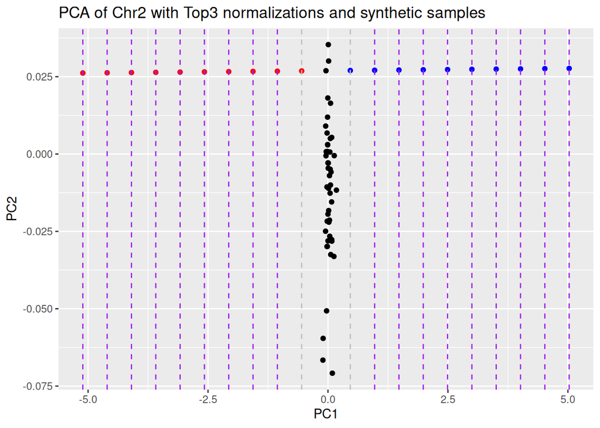

Significant synthetic samples

| Samples | PC1_values |
| --- | --- |
| sample_Chr2_Trisomy20 | 0.9720914 |
| sample_Chr2_Monosomy20 | -1.0550171 |
| sample_Chr2_Trisomy30 | 1.4788685 |
| sample_Chr2_Monosomy30 | -1.5617942 |
| sample_Chr2_Trisomy40 | 1.9856457 |
| sample_Chr2_Monosomy40 | -2.0685713 |
| sample_Chr2_Trisomy50 | 2.4924228 |
| sample_Chr2_Monosomy50 | -2.5753485 |
| sample_Chr2_Trisomy60 | 2.9991999 |
| sample_Chr2_Monosomy60 | -3.0821256 |
| sample_Chr2_Trisomy70 | 3.5059771 |
| sample_Chr2_Monosomy70 | -3.5889027 |
| sample_Chr2_Trisomy80 | 4.0127542 |
| sample_Chr2_Monosomy80 | -4.0956799 |
| sample_Chr2_Trisomy90 | 4.5195313 |
| sample_Chr2_Monosomy90 | -4.6024570 |
| sample_Chr2_Trisomy100 | 5.0263084 |
| sample_Chr2_Monosomy100 | -5.1092341 |

#### Chr3

Top 3 normalizations

| Normalized_by | SD_value |
| --- | --- |
| Norm_Chr4 | 0.0052069 |
| Norm_all | 0.0052521 |
| Norm_Chr14 | 0.0058296 |

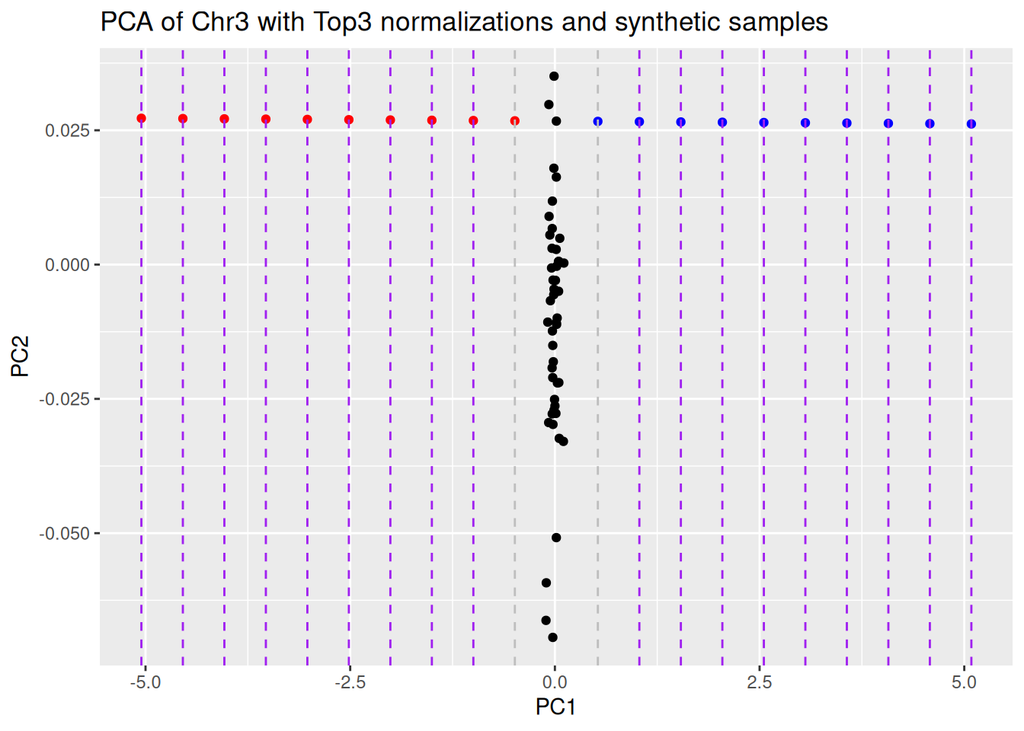

Significant synthetic samples

| Samples | PC1_values |
| --- | --- |
| sample_Chr3_Trisomy20 | 1.0317018 |
| sample_Chr3_Monosomy20 | -0.9957995 |
| sample_Chr3_Trisomy30 | 1.5385771 |
| sample_Chr3_Monosomy30 | -1.5026748 |
| sample_Chr3_Trisomy40 | 2.0454525 |
| sample_Chr3_Monosomy40 | -2.0095501 |
| sample_Chr3_Trisomy50 | 2.5523278 |
| sample_Chr3_Monosomy50 | -2.5164254 |
| sample_Chr3_Trisomy60 | 3.0592031 |
| sample_Chr3_Monosomy60 | -3.0233007 |
| sample_Chr3_Trisomy70 | 3.5660784 |
| sample_Chr3_Monosomy70 | -3.5301760 |
| sample_Chr3_Trisomy80 | 4.0729537 |
| sample_Chr3_Monosomy80 | -4.0370514 |
| sample_Chr3_Trisomy90 | 4.5798290 |
| sample_Chr3_Monosomy90 | -4.5439267 |
| sample_Chr3_Trisomy100 | 5.0867044 |
| sample_Chr3_Monosomy100 | -5.0508020 |

#### Chr4

Top 3 normalizations

| Normalized_by | SD_value |
| --- | --- |
| Norm_all | 0.0044092 |
| Norm_Chr11 | 0.0049745 |
| Norm_Chr3 | 0.0052337 |

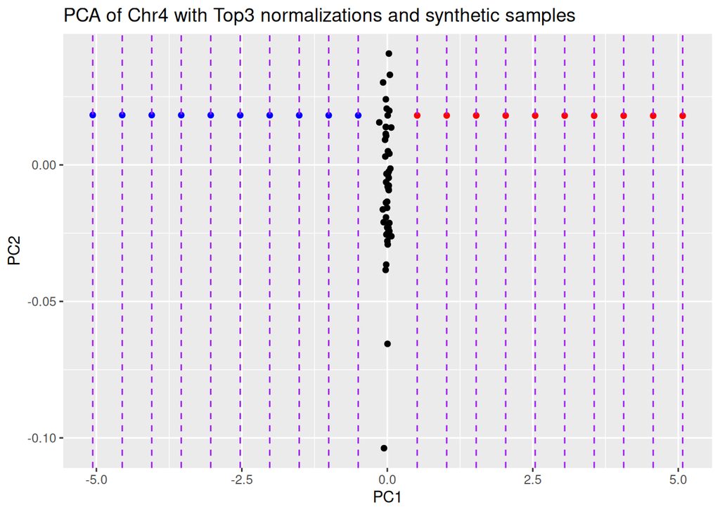

Significant synthetic samples

| Samples | PC1_values |
| --- | --- |
| sample_Chr4_Trisomy10 | -0.5001475 |
| sample_Chr4_Monosomy10 | 0.5137107 |
| sample_Chr4_Trisomy20 | -1.0070766 |
| sample_Chr4_Monosomy20 | 1.0206399 |
| sample_Chr4_Trisomy30 | -1.5140058 |
| sample_Chr4_Monosomy30 | 1.5275690 |
| sample_Chr4_Trisomy40 | -2.0209349 |
| sample_Chr4_Monosomy40 | 2.0344981 |
| sample_Chr4_Trisomy50 | -2.5278640 |
| sample_Chr4_Monosomy50 | 2.5414272 |
| sample_Chr4_Trisomy60 | -3.0347931 |
| sample_Chr4_Monosomy60 | 3.0483564 |
| sample_Chr4_Trisomy70 | -3.5417223 |
| sample_Chr4_Monosomy70 | 3.5552855 |
| sample_Chr4_Trisomy80 | -4.0486514 |
| sample_Chr4_Monosomy80 | 4.0622146 |
| sample_Chr4_Trisomy90 | -4.5555805 |
| sample_Chr4_Monosomy90 | 4.5691437 |
| sample_Chr4_Trisomy100 | -5.0625096 |
| sample_Chr4_Monosomy100 | 5.0760729 |

#### Chr5

Top 3 normalizations

| Normalized_by | SD_value |
| --- | --- |
| Norm_all | 0.0051033 |
| Norm_Chr17 | 0.0059512 |
| Norm_Chr20 | 0.0060018 |

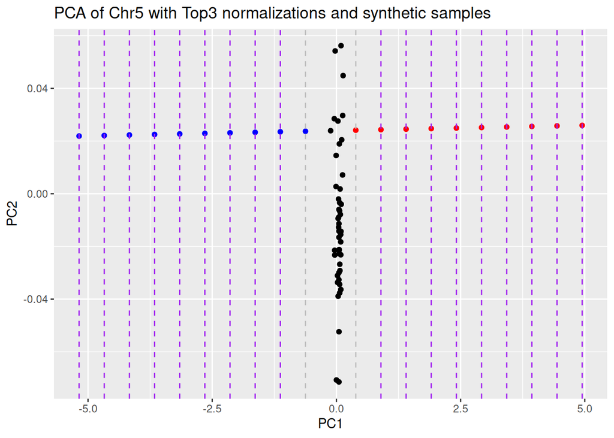

Significant synthetic samples

| Samples | PC1_values |
| --- | --- |
| sample_Chr5_Trisomy10 | -0.6226288 |
| sample_Chr5_Trisomy20 | -1.1290155 |
| sample_Chr5_Monosomy20 | 0.8965312 |
| sample_Chr5_Trisomy30 | -1.6354022 |
| sample_Chr5_Monosomy30 | 1.4029179 |
| sample_Chr5_Trisomy40 | -2.1417889 |
| sample_Chr5_Monosomy40 | 1.9093046 |
| sample_Chr5_Trisomy50 | -2.6481756 |
| sample_Chr5_Monosomy50 | 2.4156913 |
| sample_Chr5_Trisomy60 | -3.1545623 |
| sample_Chr5_Monosomy60 | 2.9220780 |
| sample_Chr5_Trisomy70 | -3.6609490 |
| sample_Chr5_Monosomy70 | 3.4284647 |
| sample_Chr5_Trisomy80 | -4.1673357 |
| sample_Chr5_Monosomy80 | 3.9348514 |
| sample_Chr5_Trisomy90 | -4.6737224 |
| sample_Chr5_Monosomy90 | 4.4412381 |
| sample_Chr5_Trisomy100 | -5.1801091 |
| sample_Chr5_Monosomy100 | 4.9476248 |

#### Chr6

Top 3 normalizations

| Normalized_by | SD_value |
| --- | --- |
| Norm_all | 0.0044591 |
| Norm_Chr11 | 0.0057925 |
| Norm_Chr9 | 0.0060537 |

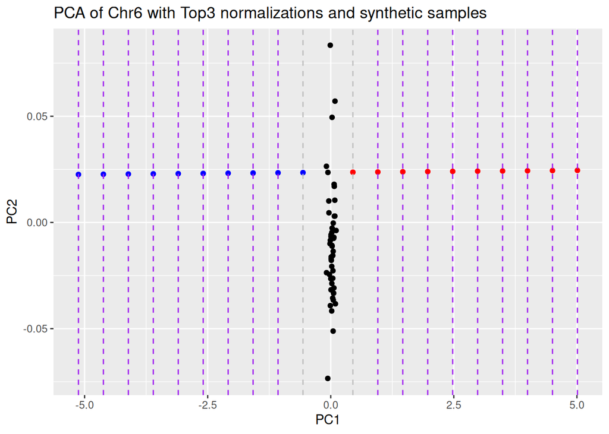

Significant synthetic samples

| Samples | PC1_values |
| --- | --- |
| sample_Chr6_Trisomy10 | -0.5638686 |
| sample_Chr6_Trisomy20 | -1.0706407 |
| sample_Chr6_Monosomy20 | 0.9564478 |
| sample_Chr6_Trisomy30 | -1.5774128 |
| sample_Chr6_Monosomy30 | 1.4632199 |
| sample_Chr6_Trisomy40 | -2.0841849 |
| sample_Chr6_Monosomy40 | 1.9699920 |
| sample_Chr6_Trisomy50 | -2.5909570 |
| sample_Chr6_Monosomy50 | 2.4767641 |
| sample_Chr6_Trisomy60 | -3.0977291 |
| sample_Chr6_Monosomy60 | 2.9835362 |
| sample_Chr6_Trisomy70 | -3.6045012 |
| sample_Chr6_Monosomy70 | 3.4903083 |
| sample_Chr6_Trisomy80 | -4.1112733 |
| sample_Chr6_Monosomy80 | 3.9970804 |
| sample_Chr6_Trisomy90 | -4.6180454 |
| sample_Chr6_Monosomy90 | 4.5038525 |
| sample_Chr6_Trisomy100 | -5.1248176 |
| sample_Chr6_Monosomy100 | 5.0106247 |

#### Chr7

Top 3 normalizations

| Normalized_by | SD_value |
| --- | --- |
| Norm_all | 0.0052059 |
| Norm_Chr22 | 0.0053222 |
| Norm_Chr17 | 0.0055608 |

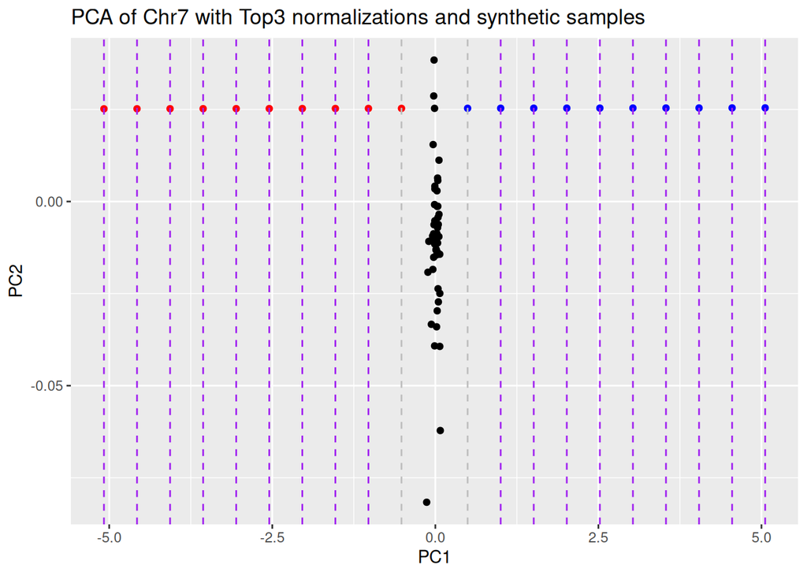

Significant synthetic samples

| Samples | PC1_values |
| --- | --- |
| sample_Chr7_Monosomy10 | -0.5188571 |
| sample_Chr7_Trisomy20 | 1.0018069 |
| sample_Chr7_Monosomy20 | -1.0257451 |
| sample_Chr7_Trisomy30 | 1.5086949 |
| sample_Chr7_Monosomy30 | -1.5326331 |
| sample_Chr7_Trisomy40 | 2.0155830 |
| sample_Chr7_Monosomy40 | -2.0395212 |
| sample_Chr7_Trisomy50 | 2.5224710 |
| sample_Chr7_Monosomy50 | -2.5464092 |
| sample_Chr7_Trisomy60 | 3.0293590 |
| sample_Chr7_Monosomy60 | -3.0532972 |
| sample_Chr7_Trisomy70 | 3.5362470 |
| sample_Chr7_Monosomy70 | -3.5601852 |
| sample_Chr7_Trisomy80 | 4.0431350 |
| sample_Chr7_Monosomy80 | -4.0670732 |
| sample_Chr7_Trisomy90 | 4.5500230 |
| sample_Chr7_Monosomy90 | -4.5739612 |
| sample_Chr7_Trisomy100 | 5.0569110 |
| sample_Chr7_Monosomy100 | -5.0808492 |

#### Chr8

Top 3 normalizations

| Normalized_by | SD_value |
| --- | --- |
| Norm_all | 0.0048113 |
| Norm_Chr14 | 0.0052512 |
| Norm_Chr4 | 0.0052634 |

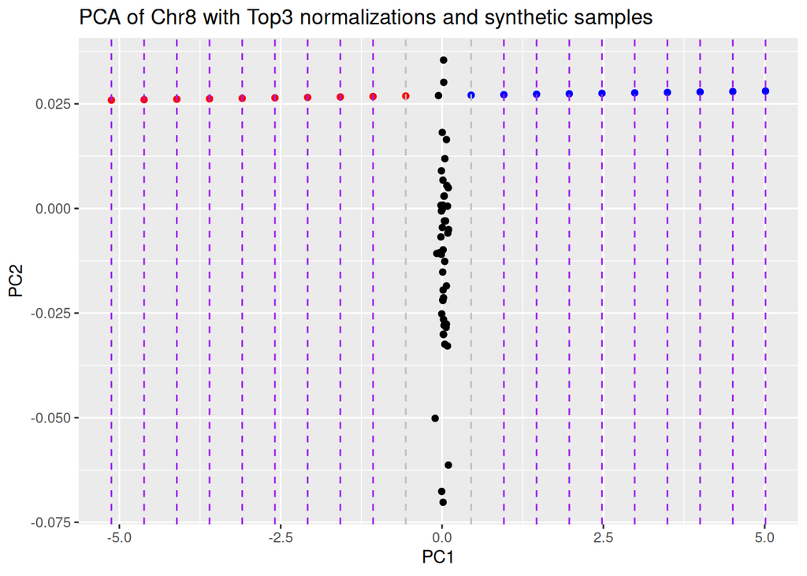

Significant synthetic samples

| Samples | PC1_values |
| --- | --- |
| sample_Chr8_Monosomy10 | -0.5624216 |
| sample_Chr8_Trisomy20 | 0.9579516 |
| sample_Chr8_Monosomy20 | -1.0692127 |
| sample_Chr8_Trisomy30 | 1.4647427 |
| sample_Chr8_Monosomy30 | -1.5760038 |
| sample_Chr8_Trisomy40 | 1.9715338 |
| sample_Chr8_Monosomy40 | -2.0827949 |
| sample_Chr8_Trisomy50 | 2.4783248 |
| sample_Chr8_Monosomy50 | -2.5895860 |
| sample_Chr8_Trisomy60 | 2.9851159 |
| sample_Chr8_Monosomy60 | -3.0963770 |
| sample_Chr8_Trisomy70 | 3.4919070 |
| sample_Chr8_Monosomy70 | -3.6031681 |
| sample_Chr8_Trisomy80 | 3.9986981 |
| sample_Chr8_Monosomy80 | -4.1099592 |
| sample_Chr8_Trisomy90 | 4.5054892 |
| sample_Chr8_Monosomy90 | -4.6167503 |
| sample_Chr8_Trisomy100 | 5.0122802 |
| sample_Chr8_Monosomy100 | -5.1235414 |

#### Chr9

Top 3 normalizations

| Normalized_by | SD_value |
| --- | --- |
| Norm_all | 0.0048167 |
| Norm_Chr10 | 0.0057056 |
| Norm_Chr22 | 0.0057470 |

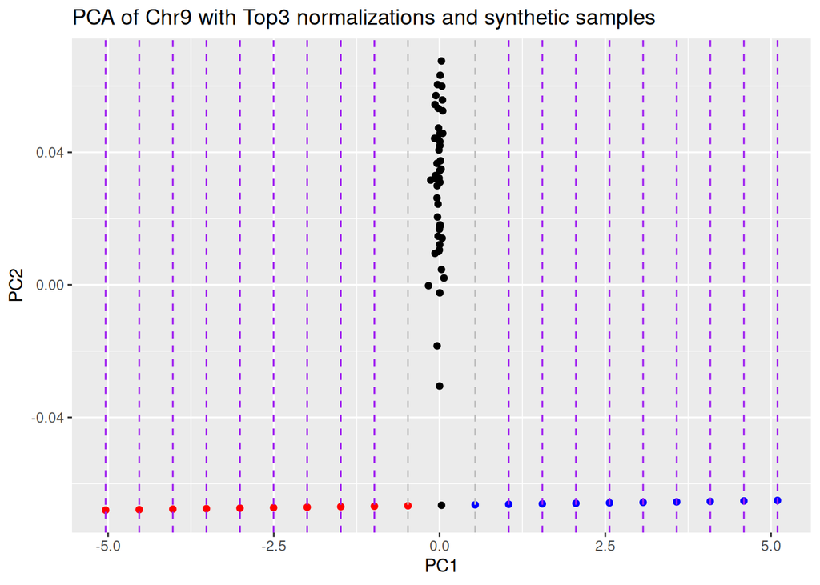

Significant synthetic samples

| Samples | PC1_values |
| --- | --- |
| sample_Chr9_Trisomy10 | 0.5369535 |
| sample_Chr9_Trisomy20 | 1.0436729 |
| sample_Chr9_Monosomy20 | -0.9832046 |
| sample_Chr9_Trisomy30 | 1.5503923 |
| sample_Chr9_Monosomy30 | -1.4899240 |
| sample_Chr9_Trisomy40 | 2.0571117 |
| sample_Chr9_Monosomy40 | -1.9966434 |
| sample_Chr9_Trisomy50 | 2.5638310 |
| sample_Chr9_Monosomy50 | -2.5033627 |
| sample_Chr9_Trisomy60 | 3.0705504 |
| sample_Chr9_Monosomy60 | -3.0100821 |
| sample_Chr9_Trisomy70 | 3.5772698 |
| sample_Chr9_Monosomy70 | -3.5168015 |
| sample_Chr9_Trisomy80 | 4.0839892 |
| sample_Chr9_Monosomy80 | -4.0235209 |
| sample_Chr9_Trisomy90 | 4.5907085 |
| sample_Chr9_Monosomy90 | -4.5302402 |
| sample_Chr9_Trisomy100 | 5.0974279 |
| sample_Chr9_Monosomy100 | -5.0369596 |

#### Chr10

Top 3 normalizations

| Normalized_by | SD_value |
| --- | --- |
| Norm_all | 0.0048191 |
| Norm_Chr9 | 0.0057007 |
| Norm_Chr17 | 0.0057029 |

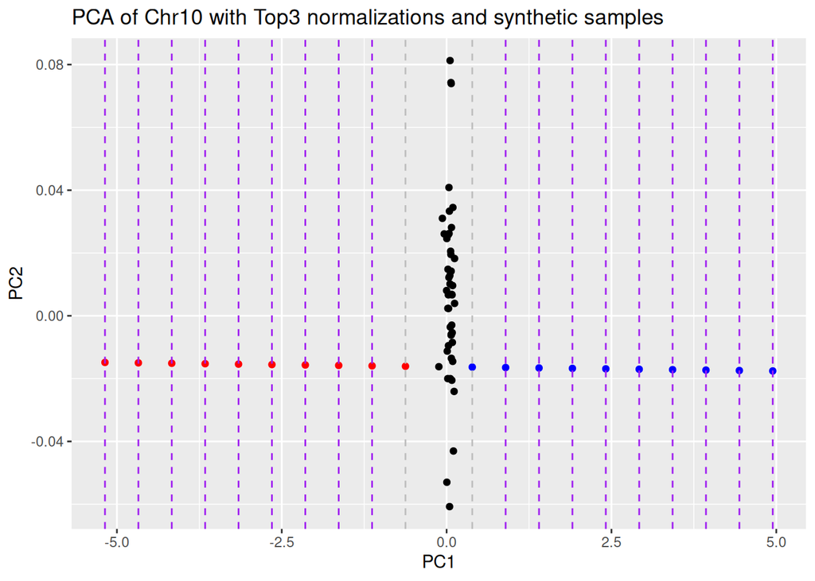

Significant synthetic samples

| Samples | PC1_values |
| --- | --- |
| sample_Chr10_Monosomy10 | -0.6236951 |
| sample_Chr10_Trisomy20 | 0.8954810 |
| sample_Chr10_Monosomy20 | -1.1300871 |
| sample_Chr10_Trisomy30 | 1.4018730 |
| sample_Chr10_Monosomy30 | -1.6364791 |
| sample_Chr10_Trisomy40 | 1.9082651 |
| sample_Chr10_Monosomy40 | -2.1428711 |
| sample_Chr10_Trisomy50 | 2.4146571 |
| sample_Chr10_Monosomy50 | -2.6492632 |
| sample_Chr10_Trisomy60 | 2.9210491 |
| sample_Chr10_Monosomy60 | -3.1556552 |
| sample_Chr10_Trisomy70 | 3.4274411 |
| sample_Chr10_Monosomy70 | -3.6620472 |
| sample_Chr10_Trisomy80 | 3.9338332 |
| sample_Chr10_Monosomy80 | -4.1684392 |
| sample_Chr10_Trisomy90 | 4.4402252 |
| sample_Chr10_Monosomy90 | -4.6748313 |
| sample_Chr10_Trisomy100 | 4.9466172 |
| sample_Chr10_Monosomy100 | -5.1812233 |

#### Chr11

Top 3 normalizations

| Normalized_by | SD_value |
| --- | --- |
| Norm_all | 0.0038201 |
| Norm_Chr4 | 0.0049570 |
| Norm_Chr12 | 0.0051087 |

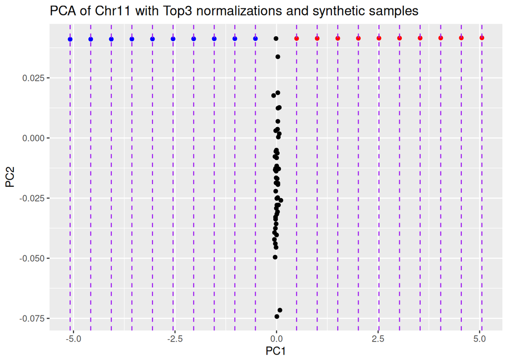

Significant synthetic samples

| Samples | PC1_values |
| --- | --- |
| sample_Chr11_Trisomy10 | -0.5202660 |
| sample_Chr11_Monosomy10 | 0.4935179 |
| sample_Chr11_Trisomy20 | -1.0271580 |
| sample_Chr11_Monosomy20 | 1.0004098 |
| sample_Chr11_Trisomy30 | -1.5340499 |
| sample_Chr11_Monosomy30 | 1.5073017 |
| sample_Chr11_Trisomy40 | -2.0409418 |
| sample_Chr11_Monosomy40 | 2.0141937 |
| sample_Chr11_Trisomy50 | -2.5478338 |
| sample_Chr11_Monosomy50 | 2.5210856 |
| sample_Chr11_Trisomy60 | -3.0547257 |
| sample_Chr11_Monosomy60 | 3.0279776 |
| sample_Chr11_Trisomy70 | -3.5616177 |
| sample_Chr11_Monosomy70 | 3.5348695 |
| sample_Chr11_Trisomy80 | -4.0685096 |
| sample_Chr11_Monosomy80 | 4.0417614 |
| sample_Chr11_Trisomy90 | -4.5754016 |
| sample_Chr11_Monosomy90 | 4.5486534 |
| sample_Chr11_Trisomy100 | -5.0822935 |
| sample_Chr11_Monosomy100 | 5.0555453 |

#### Chr12

Top 3 normalizations

| Normalized_by | SD_value |
| --- | --- |
| Norm_Chr11 | 0.0051077 |
| Norm_all | 0.0051569 |
| Norm_Chr4 | 0.0056838 |

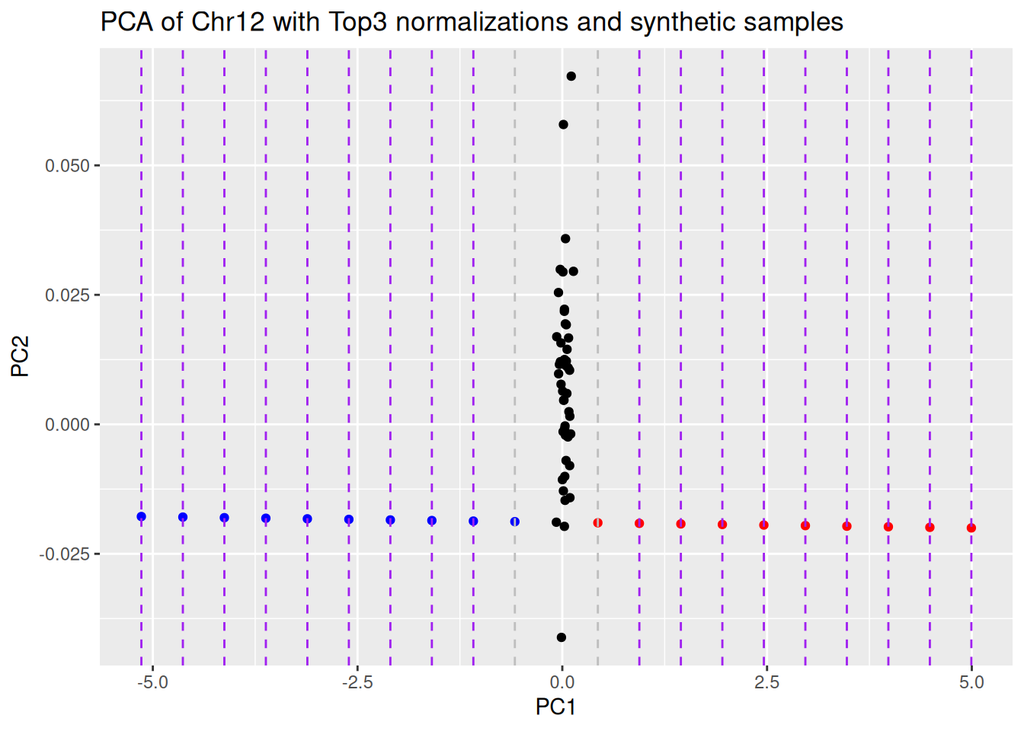

Significant synthetic samples

| Samples | PC1_values |
| --- | --- |
| sample_Chr12_Trisomy20 | -1.0860225 |
| sample_Chr12_Monosomy20 | 0.9408446 |
| sample_Chr12_Trisomy30 | -1.5927393 |
| sample_Chr12_Monosomy30 | 1.4475614 |
| sample_Chr12_Trisomy40 | -2.0994561 |
| sample_Chr12_Monosomy40 | 1.9542782 |
| sample_Chr12_Trisomy50 | -2.6061729 |
| sample_Chr12_Monosomy50 | 2.4609950 |
| sample_Chr12_Trisomy60 | -3.1128896 |
| sample_Chr12_Monosomy60 | 2.9677118 |
| sample_Chr12_Trisomy70 | -3.6196064 |
| sample_Chr12_Monosomy70 | 3.4744285 |
| sample_Chr12_Trisomy80 | -4.1263232 |
| sample_Chr12_Monosomy80 | 3.9811453 |
| sample_Chr12_Trisomy90 | -4.6330400 |
| sample_Chr12_Monosomy90 | 4.4878621 |
| sample_Chr12_Trisomy100 | -5.1397568 |
| sample_Chr12_Monosomy100 | 4.9945789 |

#### Chr13

Top 3 normalizations

| Normalized_by | SD_value |
| --- | --- |
| Norm_all | 0.0051211 |
| Norm_Chr10 | 0.0055037 |
| Norm_Chr14 | 0.0057224 |

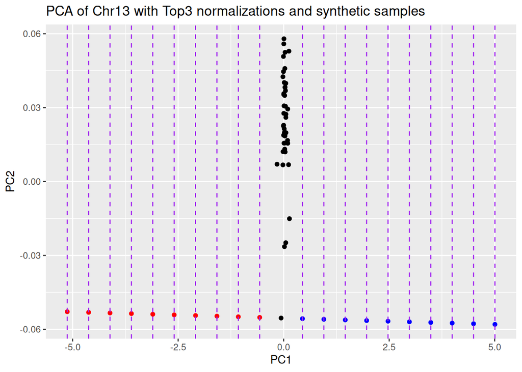

Significant synthetic samples

| Samples | PC1_values |
| --- | --- |
| sample_Chr13_Trisomy10 | 0.4456705 |
| sample_Chr13_Monosomy10 | -0.5676503 |
| sample_Chr13_Trisomy20 | 0.9523308 |
| sample_Chr13_Monosomy20 | -1.0743106 |
| sample_Chr13_Trisomy30 | 1.4589912 |
| sample_Chr13_Monosomy30 | -1.5809710 |
| sample_Chr13_Trisomy40 | 1.9656516 |
| sample_Chr13_Monosomy40 | -2.0876313 |
| sample_Chr13_Trisomy50 | 2.4723119 |
| sample_Chr13_Monosomy50 | -2.5942917 |
| sample_Chr13_Trisomy60 | 2.9789723 |
| sample_Chr13_Monosomy60 | -3.1009521 |
| sample_Chr13_Trisomy70 | 3.4856326 |
| sample_Chr13_Monosomy70 | -3.6076124 |
| sample_Chr13_Trisomy80 | 3.9922930 |
| sample_Chr13_Monosomy80 | -4.1142728 |
| sample_Chr13_Trisomy90 | 4.4989534 |
| sample_Chr13_Monosomy90 | -4.6209332 |
| sample_Chr13_Trisomy100 | 5.0056137 |
| sample_Chr13_Monosomy100 | -5.1275935 |

#### Chr14

Top 3 normalizations

| Normalized_by | SD_value |
| --- | --- |
| Norm_all | 0.0039754 |
| Norm_Chr8 | 0.0052810 |
| Norm_Chr11 | 0.0053001 |

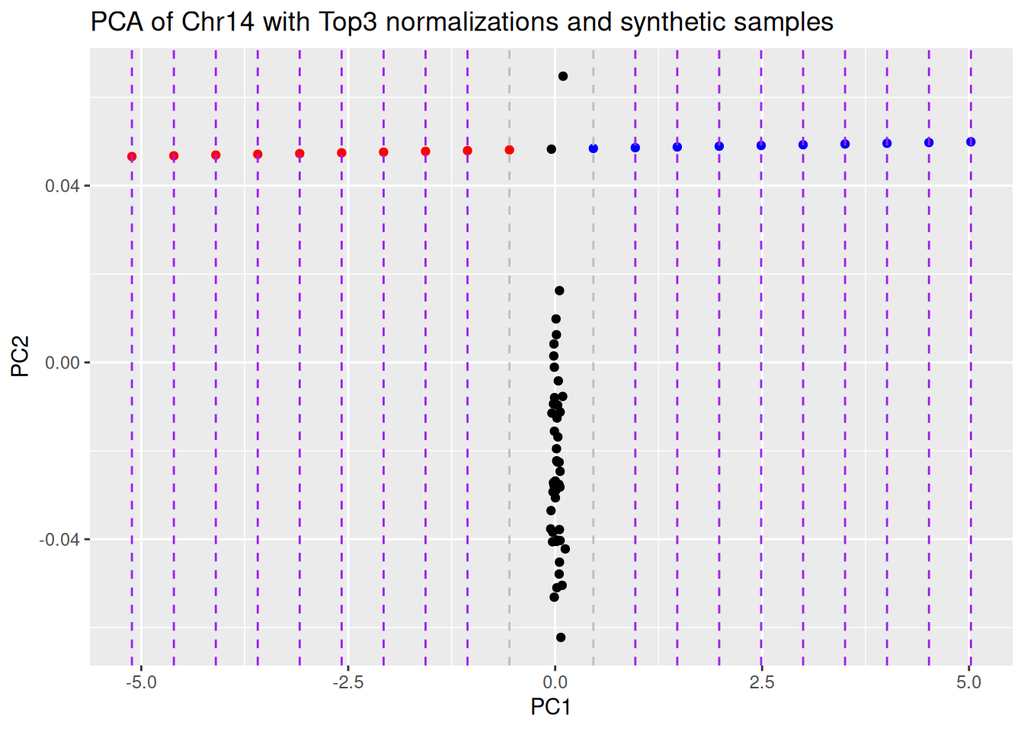

Significant synthetic samples

| Samples | PC1_values |
| --- | --- |
| sample_Chr14_Monosomy10 | -0.5519828 |
| sample_Chr14_Trisomy20 | 0.9683764 |
| sample_Chr14_Monosomy20 | -1.0587693 |
| sample_Chr14_Trisomy30 | 1.4751628 |
| sample_Chr14_Monosomy30 | -1.5655557 |
| sample_Chr14_Trisomy40 | 1.9819492 |
| sample_Chr14_Monosomy40 | -2.0723421 |
| sample_Chr14_Trisomy50 | 2.4887356 |
| sample_Chr14_Monosomy50 | -2.5791285 |
| sample_Chr14_Trisomy60 | 2.9955220 |
| sample_Chr14_Monosomy60 | -3.0859149 |
| sample_Chr14_Trisomy70 | 3.5023084 |
| sample_Chr14_Monosomy70 | -3.5927013 |
| sample_Chr14_Trisomy80 | 4.0090948 |
| sample_Chr14_Monosomy80 | -4.0994877 |
| sample_Chr14_Trisomy90 | 4.5158812 |
| sample_Chr14_Monosomy90 | -4.6062741 |
| sample_Chr14_Trisomy100 | 5.0226676 |
| sample_Chr14_Monosomy100 | -5.1130605 |

#### Chr15

Top 3 normalizations

| Normalized_by | SD_value |
| --- | --- |
| Norm_all | 0.0043987 |
| Norm_Chr20 | 0.0047997 |
| Norm_Chr22 | 0.0056572 |

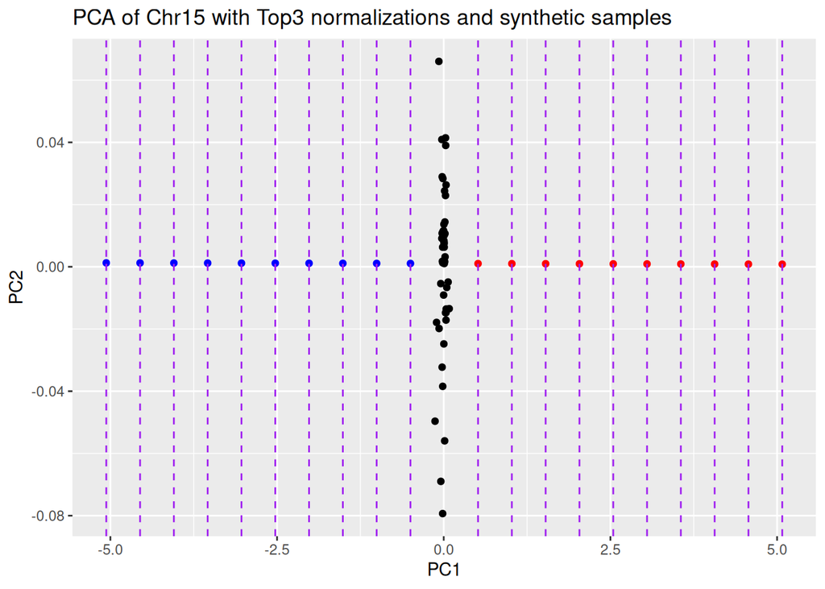

Significant synthetic samples

| Samples | PC1_values |
| --- | --- |
| sample_Chr15_Trisomy10 | -0.4992356 |
| sample_Chr15_Monosomy10 | 0.5146403 |
| sample_Chr15_Trisomy20 | -1.0061736 |
| sample_Chr15_Monosomy20 | 1.0215783 |
| sample_Chr15_Trisomy30 | -1.5131116 |
| sample_Chr15_Monosomy30 | 1.5285163 |
| sample_Chr15_Trisomy40 | -2.0200496 |
| sample_Chr15_Monosomy40 | 2.0354543 |
| sample_Chr15_Trisomy50 | -2.5269876 |
| sample_Chr15_Monosomy50 | 2.5423923 |
| sample_Chr15_Trisomy60 | -3.0339255 |
| sample_Chr15_Monosomy60 | 3.0493302 |
| sample_Chr15_Trisomy70 | -3.5408635 |
| sample_Chr15_Monosomy70 | 3.5562682 |
| sample_Chr15_Trisomy80 | -4.0478015 |
| sample_Chr15_Monosomy80 | 4.0632062 |
| sample_Chr15_Trisomy90 | -4.5547395 |
| sample_Chr15_Monosomy90 | 4.5701442 |
| sample_Chr15_Trisomy100 | -5.0616775 |
| sample_Chr15_Monosomy100 | 5.0770822 |

#### Chr16

Top 3 normalizations

| Normalized_by | SD_value |
| --- | --- |
| Norm_all | 0.0057678 |
| Norm_Chr20 | 0.0061028 |
| Norm_Chr5 | 0.0061122 |

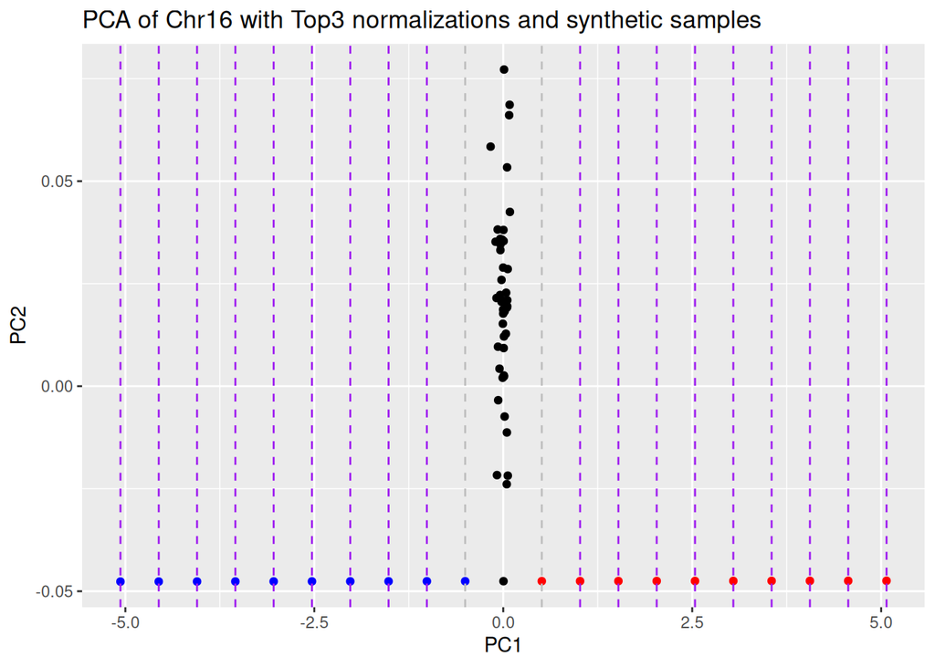

Significant synthetic samples

| Samples | PC1_values |
| --- | --- |
| sample_Chr16_Trisomy20 | -1.010544 |
| sample_Chr16_Monosomy20 | 1.016621 |
| sample_Chr16_Trisomy30 | -1.517335 |
| sample_Chr16_Monosomy30 | 1.523413 |
| sample_Chr16_Trisomy40 | -2.024126 |
| sample_Chr16_Monosomy40 | 2.030204 |
| sample_Chr16_Trisomy50 | -2.530918 |
| sample_Chr16_Monosomy50 | 2.536995 |
| sample_Chr16_Trisomy60 | -3.037709 |
| sample_Chr16_Monosomy60 | 3.043786 |
| sample_Chr16_Trisomy70 | -3.544500 |
| sample_Chr16_Monosomy70 | 3.550578 |
| sample_Chr16_Trisomy80 | -4.051291 |
| sample_Chr16_Monosomy80 | 4.057369 |
| sample_Chr16_Trisomy90 | -4.558083 |
| sample_Chr16_Monosomy90 | 4.564160 |
| sample_Chr16_Trisomy100 | -5.064874 |
| sample_Chr16_Monosomy100 | 5.070951 |

#### Chr17

Top 3 normalizations

| Normalized_by | SD_value |
| --- | --- |
| Norm_all | 0.0043276 |
| Norm_Chr22 | 0.0050969 |
| Norm_Chr7 | 0.0056355 |

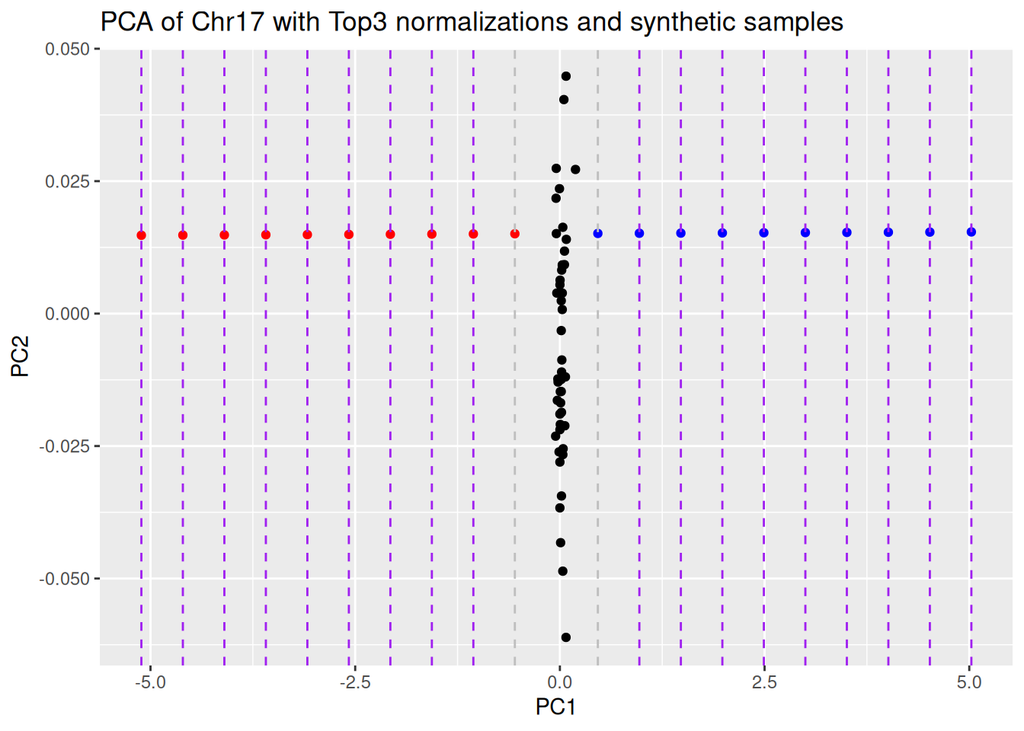

Significant synthetic samples

| Samples | PC1_values |
| --- | --- |
| sample_Chr17_Monosomy10 | -0.5498941 |
| sample_Chr17_Trisomy20 | 0.9706875 |
| sample_Chr17_Monosomy20 | -1.0567546 |
| sample_Chr17_Trisomy30 | 1.4775480 |
| sample_Chr17_Monosomy30 | -1.5636152 |
| sample_Chr17_Trisomy40 | 1.9844085 |
| sample_Chr17_Monosomy40 | -2.0704757 |
| sample_Chr17_Trisomy50 | 2.4912691 |
| sample_Chr17_Monosomy50 | -2.5773362 |
| sample_Chr17_Trisomy60 | 2.9981296 |
| sample_Chr17_Monosomy60 | -3.0841968 |
| sample_Chr17_Trisomy70 | 3.5049901 |
| sample_Chr17_Monosomy70 | -3.5910573 |
| sample_Chr17_Trisomy80 | 4.0118507 |
| sample_Chr17_Monosomy80 | -4.0979178 |
| sample_Chr17_Trisomy90 | 4.5187112 |
| sample_Chr17_Monosomy90 | -4.6047783 |
| sample_Chr17_Trisomy100 | 5.0255717 |
| sample_Chr17_Monosomy100 | -5.1116389 |

#### Chr18

Top 3 normalizations

| Normalized_by | SD_value |
| --- | --- |
| Norm_all | 0.0038201 |
| Norm_Chr11 | 0.0049880 |
| Norm_Chr15 | 0.0051497 |

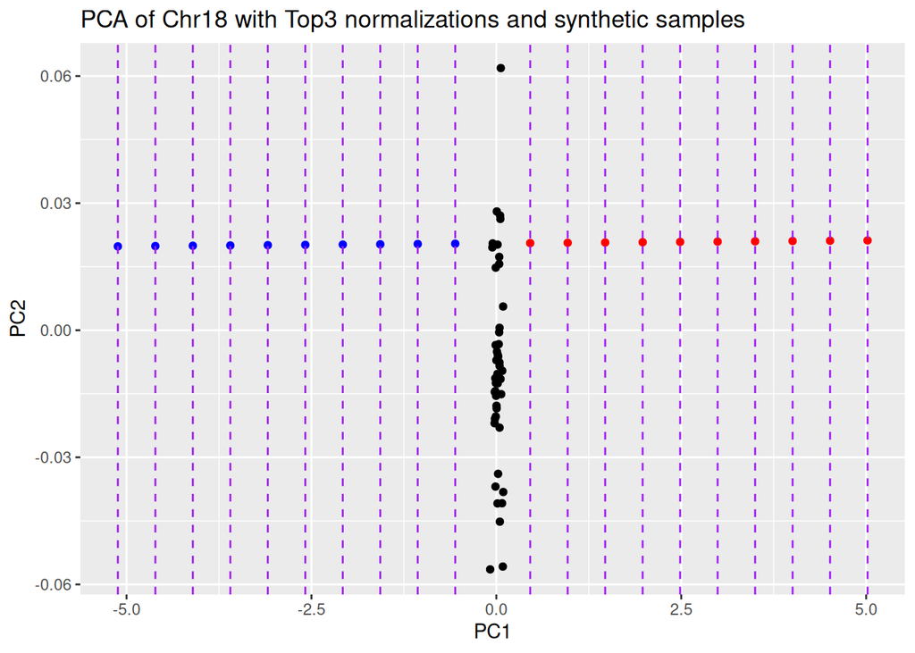

Significant synthetic samples

| Samples | PC1_values |
| --- | --- |
| sample_Chr18_Trisomy10 | -0.5558280 |
| sample_Chr18_Monosomy10 | 0.4578833 |
| sample_Chr18_Trisomy20 | -1.0626837 |
| sample_Chr18_Monosomy20 | 0.9647389 |
| sample_Chr18_Trisomy30 | -1.5695393 |
| sample_Chr18_Monosomy30 | 1.4715946 |
| sample_Chr18_Trisomy40 | -2.0763950 |
| sample_Chr18_Monosomy40 | 1.9784502 |
| sample_Chr18_Trisomy50 | -2.5832506 |
| sample_Chr18_Monosomy50 | 2.4853059 |
| sample_Chr18_Trisomy60 | -3.0901063 |
| sample_Chr18_Monosomy60 | 2.9921615 |
| sample_Chr18_Trisomy70 | -3.5969619 |
| sample_Chr18_Monosomy70 | 3.4990172 |
| sample_Chr18_Trisomy80 | -4.1038176 |
| sample_Chr18_Monosomy80 | 4.0058728 |
| sample_Chr18_Trisomy90 | -4.6106732 |
| sample_Chr18_Monosomy90 | 4.5127285 |
| sample_Chr18_Trisomy100 | -5.1175289 |
| sample_Chr18_Monosomy100 | 5.0195841 |

#### Chr19

Top 3 normalizations

| Normalized_by | SD_value |
| --- | --- |
| Norm_Chr20 | 0.0069087 |
| Norm_Chr15 | 0.0071751 |
| Norm_Chr9 | 0.0072332 |

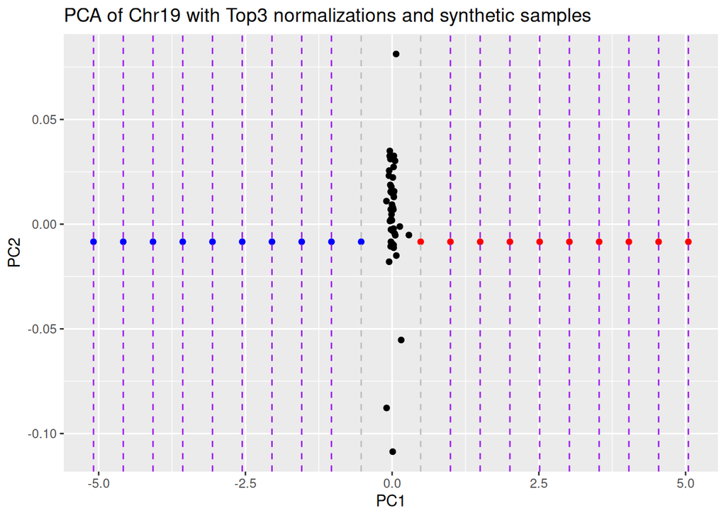

Significant synthetic samples

| Samples | PC1_values |
| --- | --- |
| sample_Chr19_Trisomy10 | -0.5270310 |
| sample_Chr19_Trisomy20 | -1.0338010 |
| sample_Chr19_Monosomy20 | 0.9932789 |
| sample_Chr19_Trisomy30 | -1.5405710 |
| sample_Chr19_Monosomy30 | 1.5000488 |
| sample_Chr19_Trisomy40 | -2.0473409 |
| sample_Chr19_Monosomy40 | 2.0068188 |
| sample_Chr19_Trisomy50 | -2.5541109 |
| sample_Chr19_Monosomy50 | 2.5135888 |
| sample_Chr19_Trisomy60 | -3.0608809 |
| sample_Chr19_Monosomy60 | 3.0203587 |
| sample_Chr19_Trisomy70 | -3.5676508 |
| sample_Chr19_Monosomy70 | 3.5271287 |
| sample_Chr19_Trisomy80 | -4.0744208 |
| sample_Chr19_Monosomy80 | 4.0338986 |
| sample_Chr19_Trisomy90 | -4.5811908 |
| sample_Chr19_Monosomy90 | 4.5406686 |
| sample_Chr19_Trisomy100 | -5.0879607 |
| sample_Chr19_Monosomy100 | 5.0474386 |

#### Chr20

Top 3 normalizations

| Normalized_by | SD_value |
| --- | --- |
| Norm_all | 0.0046137 |
| Norm_Chr15 | 0.0047988 |
| Norm_Chr5 | 0.0060248 |

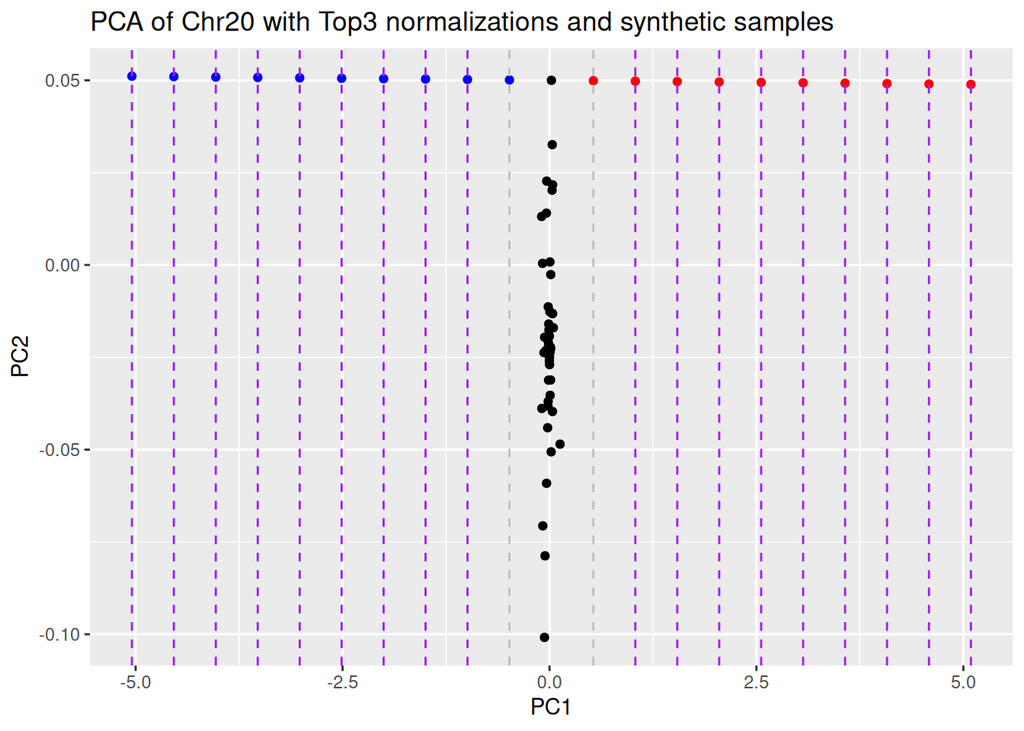

Significant synthetic samples

| Samples | PC1_values |
| --- | --- |
| sample_Chr20_Monosomy10 | 0.5298746 |
| sample_Chr20_Trisomy20 | -0.9905762 |
| sample_Chr20_Monosomy20 | 1.0366916 |
| sample_Chr20_Trisomy30 | -1.4973931 |
| sample_Chr20_Monosomy30 | 1.5435085 |
| sample_Chr20_Trisomy40 | -2.0042100 |
| sample_Chr20_Monosomy40 | 2.0503254 |
| sample_Chr20_Trisomy50 | -2.5110270 |
| sample_Chr20_Monosomy50 | 2.5571424 |
| sample_Chr20_Trisomy60 | -3.0178439 |
| sample_Chr20_Monosomy60 | 3.0639593 |
| sample_Chr20_Trisomy70 | -3.5246608 |
| sample_Chr20_Monosomy70 | 3.5707762 |
| sample_Chr20_Trisomy80 | -4.0314777 |
| sample_Chr20_Monosomy80 | 4.0775932 |
| sample_Chr20_Trisomy90 | -4.5382947 |
| sample_Chr20_Monosomy90 | 4.5844101 |
| sample_Chr20_Trisomy100 | -5.0451116 |
| sample_Chr20_Monosomy100 | 5.0912270 |

#### Chr21

Top 3 normalizations

| Normalized_by | SD_value |
| --- | --- |
| Norm_Chr11 | 0.0040442 |
| Norm_all | 0.0040503 |
| Norm_Chr4 | 0.0049602 |

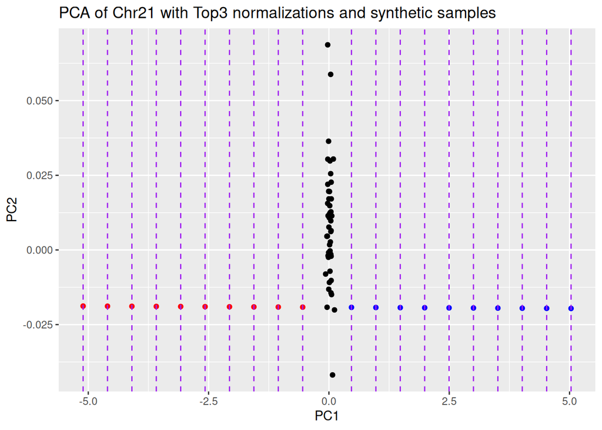

Significant synthetic samples

| Samples | PC1_values |
| --- | --- |
| sample_Chr21_Trisomy10 | 0.4686859 |
| sample_Chr21_Monosomy10 | -0.5451273 |
| sample_Chr21_Trisomy20 | 0.9755925 |
| sample_Chr21_Monosomy20 | -1.0520338 |
| sample_Chr21_Trisomy30 | 1.4824991 |
| sample_Chr21_Monosomy30 | -1.5589404 |
| sample_Chr21_Trisomy40 | 1.9894057 |
| sample_Chr21_Monosomy40 | -2.0658470 |
| sample_Chr21_Trisomy50 | 2.4963122 |
| sample_Chr21_Monosomy50 | -2.5727536 |
| sample_Chr21_Trisomy60 | 3.0032188 |
| sample_Chr21_Monosomy60 | -3.0796602 |
| sample_Chr21_Trisomy70 | 3.5101254 |
| sample_Chr21_Monosomy70 | -3.5865668 |
| sample_Chr21_Trisomy80 | 4.0170320 |
| sample_Chr21_Monosomy80 | -4.0934733 |
| sample_Chr21_Trisomy90 | 4.5239386 |
| sample_Chr21_Monosomy90 | -4.6003799 |
| sample_Chr21_Trisomy100 | 5.0308451 |
| sample_Chr21_Monosomy100 | -5.1072865 |

#### Chr22

Top 3 normalizations

| Normalized_by | SD_value |
| --- | --- |
| Norm_all | 0.0047956 |
| Norm_Chr17 | 0.0050758 |
| Norm_Chr7 | 0.0053352 |

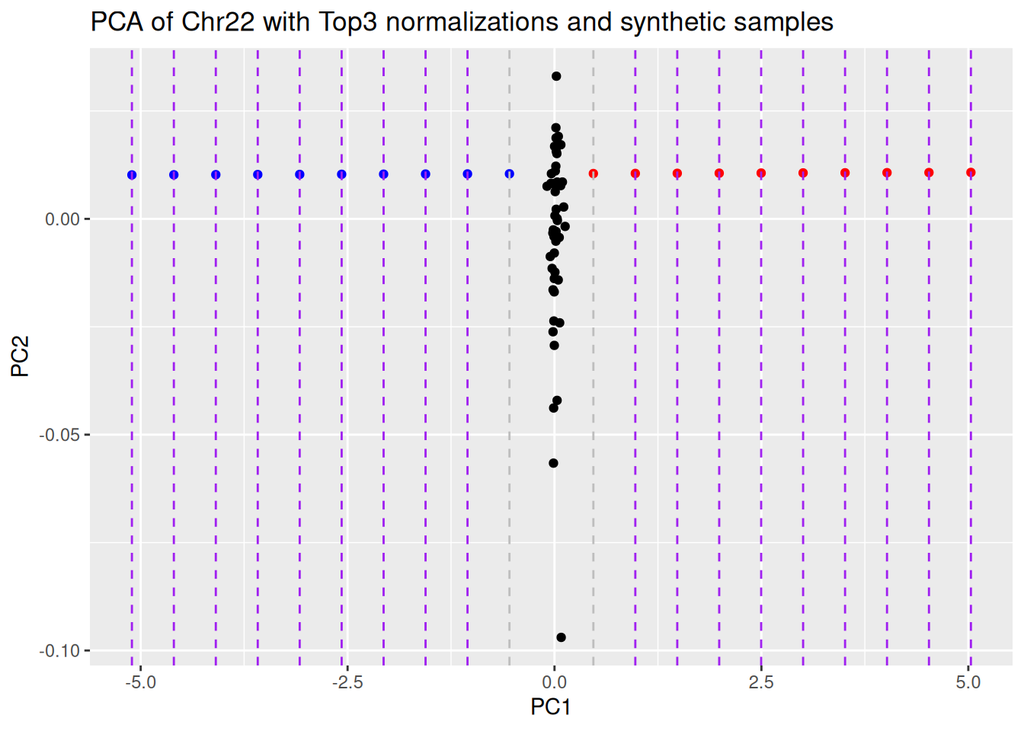

Significant synthetic samples

| Samples | PC1_values |
| --- | --- |
| sample_Chr22_Trisomy10 | -0.5441794 |
| sample_Chr22_Trisomy20 | -1.0510549 |
| sample_Chr22_Monosomy20 | 0.9764472 |
| sample_Chr22_Trisomy30 | -1.5579304 |
| sample_Chr22_Monosomy30 | 1.4833227 |
| sample_Chr22_Trisomy40 | -2.0648059 |
| sample_Chr22_Monosomy40 | 1.9901982 |
| sample_Chr22_Trisomy50 | -2.5716815 |
| sample_Chr22_Monosomy50 | 2.4970738 |
| sample_Chr22_Trisomy60 | -3.0785570 |
| sample_Chr22_Monosomy60 | 3.0039493 |
| sample_Chr22_Trisomy70 | -3.5854325 |
| sample_Chr22_Monosomy70 | 3.5108248 |
| sample_Chr22_Trisomy80 | -4.0923080 |
| sample_Chr22_Monosomy80 | 4.0177003 |
| sample_Chr22_Trisomy90 | -4.5991835 |
| sample_Chr22_Monosomy90 | 4.5245759 |
| sample_Chr22_Trisomy100 | -5.1060591 |
| sample_Chr22_Monosomy100 | 5.0314514 |

## Study of sexual chromosomes

To analyze the sex chromosomes, the average coverage value for each chromosome was calculated in the control samples. Then, different normalizations were applied by dividing this value by the average coverage of other chromosomes or specific groups.

Beta dispersion was calculated independently for the control XX and XY samples. This measure allows evaluating the internal dispersion of each cohort and, therefore, identifying which normalizations promote better clustering within each group.

Top 3 normalizations

| Normalized_by | XX_dispersion | XY_dispersion | mean_dispersion |
| --- | --- | --- | --- |
| Norm_autosomes | 0.0058444 | 0.0037991 | 0.0048218 |
| Norm_Chr6 | 0.0054243 | 0.0048386 | 0.0051315 |
| Norm_Chr11 | 0.0060835 | 0.0046203 | 0.0053519 |

### Top1

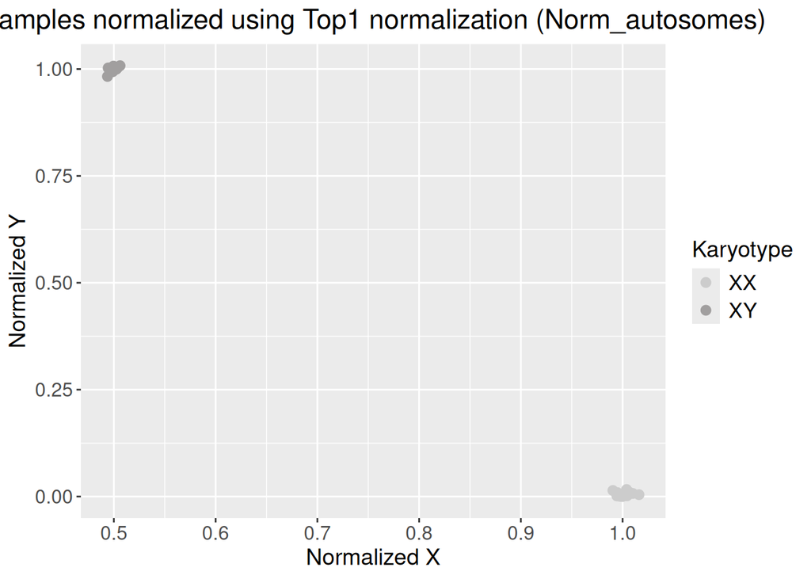

### Top2

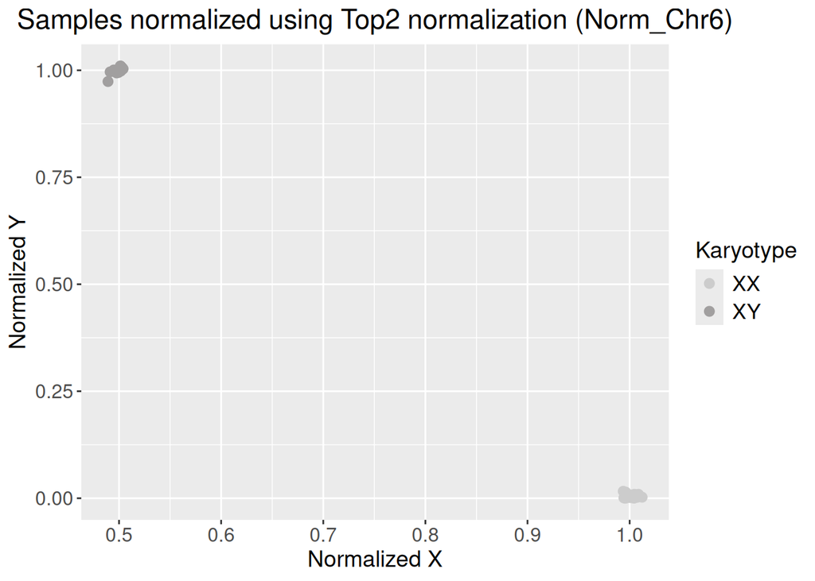

### Top3

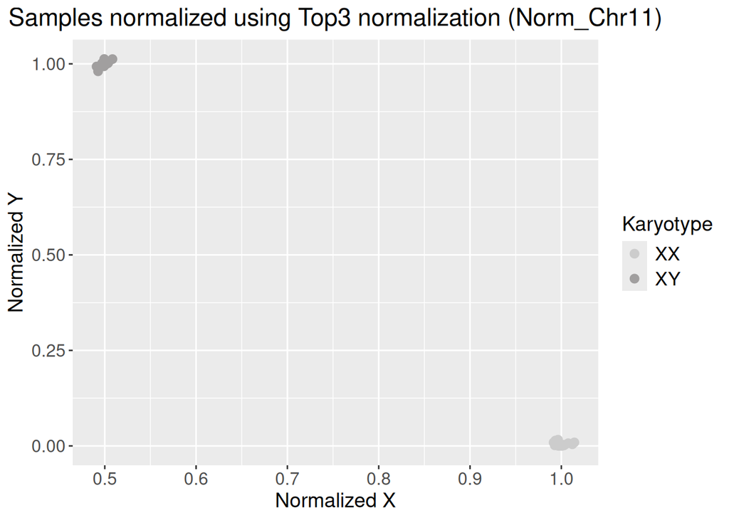